# Desafío de Detección de Intrusiones RT-IoT2022

## Comparación de Algoritmos de Machine Learning Clásicos

**Objetivo:** Clasificar tráfico IoT como normal o malicioso usando múltiples algoritmos (Logistic Regression, SVM, Decision Tree, Random Forest, k-NN) y comparar su rendimiento.

**Integrantes:** Daniel Villalba - Isaac Navarro

```python
# ============================================
# CONFIGURACIÓN E IMPORTS
# ============================================
import pandas as pd
import numpy as np
import matplotlib.pyplot as plt
import seaborn as sns
from sklearn.model_selection import train_test_split, StratifiedKFold
from sklearn.preprocessing import StandardScaler, LabelEncoder
from sklearn.linear_model import LogisticRegression
from sklearn.svm import SVC
from sklearn.tree import DecisionTreeClassifier
from sklearn.ensemble import RandomForestClassifier
from sklearn.neighbors import KNeighborsClassifier
from sklearn.metrics import (
    accuracy_score, classification_report, confusion_matrix,
    precision_score, recall_score, f1_score, roc_auc_score, roc_curve
)
import warnings
warnings.filterwarnings('ignore')

sns.set_style('whitegrid')
plt.rcParams['figure.figsize'] = (14, 6)
np.random.seed(42)

print("Librerías importadas correctamente")
```

```
Librerías importadas correctamente
```

## Dataset y Estructura de Archivos

Se trabaja con tres archivos del repositorio Taller-2-RT-IoT2022:

- **train_data.csv:** Datos de entrenamiento con etiquetas (Attack_type)
- **test_data.csv:** Datos de prueba sin etiquetas
- **test_label_data.csv:** Etiquetas de validación (opcional para verificación post-competencia)

El dataset contiene tráfico capturado en un testbed controlado usando Wireshark, con características extraídas por CICFlowmeter (puertos, protocolo, IAT, flags TCP, etc.).

```python
# ============================================
# CARGA DE DATOS ADAPTADA PARA DOS ARCHIVOS
# ============================================

TRAIN_PATH = "train_data.csv"
TEST_PATH = "test_data.csv"

train_df = pd.read_csv(TRAIN_PATH)
test_df = pd.read_csv(TEST_PATH)

print(f"Train shape: {train_df.shape}")
print(f"Test shape: {test_df.shape}")
```

```
Train shape: (92337, 85)
Test shape: (24624, 85)
```

## Análisis Exploratorio (EDA)

Se exploran dimensiones, tipos de datos, valores faltantes y distribución de clases para entender el desbalanceo y guiar decisiones de preprocesamiento.

```
================================================================================
INFO DEL DATASET DE ENTRENAMIENTO
================================================================================
Shape: (92337, 85)

Tipos de datos:
float64    56
int64      26
object      3
Name: count, dtype: int64

Valores faltantes totales: 0

Primeras 5 filas:
```

|  | id | id.orig_p | id.resp_p | proto | service | flow_duration | fwd_pkts_tot | bwd_pkts_tot | fwd_data_pkts_tot | bwd_data_pkts_tot | ... | active.std | idle.min | idle.max | idle.tot | idle.avg | idle.std | fwd_init_window_size | bwd_init_window_size | fwd_last_window_size | Attack_type |
| --- | --- | --- | --- | --- | --- | --- | --- | --- | --- | --- | --- | --- | --- | --- | --- | --- | --- | --- | --- | --- | --- |
| 0 | 3054 | 36230 | 443 | tcp | ssl | 10.644097 | 15 | 10 | 7 | 5 | ... | 411331.830867 | 9.997739e+06 | 9.997739e+06 | 9.997739e+06 | 9.997739e+06 | 0.0 | 64240 | 26544 | 501 | ARP_poisioning |
| 1 | 3576 | 57920 | 443 | tcp | ssl | 1.250508 | 13 | 12 | 3 | 9 | ... | 0.000000 | 0.000000e+00 | 0.000000e+00 | 0.000000e+00 | 0.000000e+00 | 0.0 | 64240 | 26847 | 0 | Thing_Speak |
| 2 | 74179 | 62897 | 21 | tcp | - | 0.000002 | 1 | 1 | 1 | 0 | ... | 0.000000 | 0.000000e+00 | 0.000000e+00 | 0.000000e+00 | 0.000000e+00 | 0.0 | 64 | 0 | 64 | DOS_SYN_Hping |
| 3 | 1011 | 50078 | 49186 | udp | - | 0.000000 | 1 | 0 | 1 | 0 | ... | 0.000000 | 0.000000e+00 | 0.000000e+00 | 0.000000e+00 | 0.000000e+00 | 0.0 | 0 | 0 | 0 | NMAP_UDP_SCAN |
| 4 | 74372 | 27538 | 21 | tcp | - | 0.000002 | 1 | 1 | 1 | 0 | ... | 0.000000 | 0.000000e+00 | 0.000000e+00 | 0.000000e+00 | 0.000000e+00 | 0.0 | 64 | 0 | 64 | DOS_SYN_Hping |

5 rows × 85 columns

```
Estadísticas descriptivas (primeras 10 columnas numéricas):
```

|  | id | id.orig_p | id.resp_p | flow_duration | fwd_pkts_tot | bwd_pkts_tot | fwd_data_pkts_tot | bwd_data_pkts_tot | fwd_pkts_per_sec | bwd_pkts_per_sec |
| --- | --- | --- | --- | --- | --- | --- | --- | --- | --- | --- |
| count | 92337.000000 | 92337.000000 | 92337.000000 | 92337.000000 | 92337.000000 | 92337.000000 | 92337.000000 | 92337.000000 | 9.233700e+04 | 9.233700e+04 |
| mean | 37098.792987 | 34646.767742 | 1015.004094 | 4.046150 | 2.296793 | 1.938183 | 1.483382 | 0.847353 | 3.520342e+05 | 3.519918e+05 |
| std | 30463.634584 | 19082.449153 | 5265.706203 | 145.446486 | 24.530446 | 37.560458 | 21.507715 | 36.790491 | 3.710062e+05 | 3.710417e+05 |
| min | 0.000000 | 0.000000 | 0.000000 | 0.000000 | 0.000000 | 0.000000 | 0.000000 | 0.000000 | 0.000000e+00 | 0.000000e+00 |
| 25% | 6078.000000 | 17695.000000 | 21.000000 | 0.000001 | 1.000000 | 1.000000 | 1.000000 | 0.000000 | 7.476411e+01 | 7.313712e+01 |
| 50% | 33218.000000 | 37232.000000 | 21.000000 | 0.000004 | 1.000000 | 1.000000 | 1.000000 | 0.000000 | 2.467238e+05 | 2.467238e+05 |
| 75% | 63914.000000 | 51004.000000 | 21.000000 | 0.000005 | 1.000000 | 1.000000 | 1.000000 | 0.000000 | 5.242880e+05 | 5.242880e+05 |
| max | 94658.000000 | 65535.000000 | 65389.000000 | 21728.335578 | 4345.000000 | 10112.000000 | 4345.000000 | 10105.000000 | 1.048576e+06 | 1.048576e+06 |

```
================================================================================
DISTRIBUCIÓN DE ATTACK_TYPE (Variable Objetivo)
================================================================================
Attack_type
DOS_SYN_Hping                 71027
Thing_Speak                    6025
ARP_poisioning                 5883
MQTT_Publish                   3050
NMAP_UDP_SCAN                  1943
NMAP_OS_DETECTION              1515
NMAP_XMAS_TREE_SCAN            1493
NMAP_TCP_scan                   769
DDOS_Slowloris                  404
Wipro_bulb                      188
Metasploit_Brute_Force_SSH       24
NMAP_FIN_SCAN                    16
Name: count, dtype: int64

Total de clases: 12
Clase más frecuente: DOS_SYN_Hping (71027 instancias)
Clase menos frecuente: NMAP_FIN_SCAN (16 instancias)
Ratio de desbalanceo: 4439.2:1
```

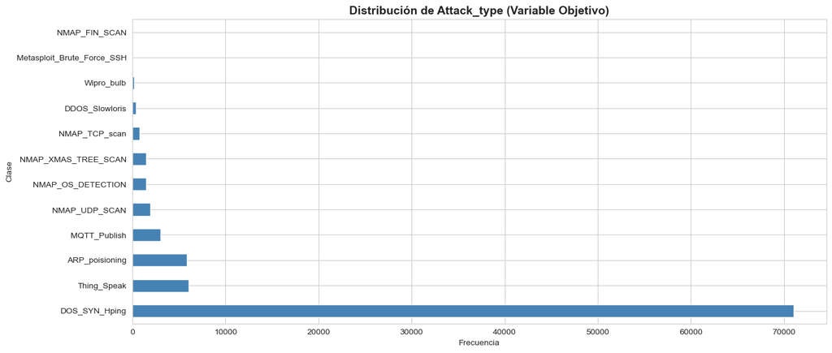

```python
# ============================================
# EDA BÁSICO
# ============================================

print("\n" + "="*80)
print("INFO DEL DATASET DE ENTRENAMIENTO")
print("="*80)
print(f"Shape: {train_df.shape}")
print(f"\nTipos de datos:")
print(train_df.dtypes.value_counts())

print(f"\nValores faltantes totales: {train_df.isnull().sum().sum()}")

print(f"\nPrimeras 5 filas:")
display(train_df.head())

print(f"\nEstadísticas descriptivas (primeras 10 columnas numéricas):")
display(train_df.describe().iloc[:, :10])

# Distribución de Attack_type
assert 'Attack_type' in train_df.columns, "Falta columna Attack_type"
dist = train_df['Attack_type'].value_counts()

print(f"\n" + "="*80)
print("DISTRIBUCIÓN DE ATTACK_TYPE (Variable Objetivo)")
print("="*80)
print(dist)
print(f"\nTotal de clases: {len(dist)}")
print(f"Clase más frecuente: {dist.index[0]} ({dist.iloc[0]} instancias)")
print(f"Clase menos frecuente: {dist.index[-1]} ({dist.iloc[-1]} instancias)")
print(f"Ratio de desbalanceo: {dist.iloc[0] / dist.iloc[-1]:.1f}:1")

# Visualizar distribución
fig, ax = plt.subplots(figsize=(14, 6))
dist.plot(kind='barh', ax=ax, color='steelblue')
ax.set_title('Distribución de Attack_type (Variable Objetivo)', fontsize=14, fontweight='bold')
ax.set_xlabel('Frecuencia')
ax.set_ylabel('Clase')
plt.tight_layout()
plt.savefig('01_distribucion_clases.png', dpi=300, bbox_inches='tight')
plt.show()
```

## Preparación de Datos: Limpieza y Codificación

Se realizan los siguientes pasos:

1. Separación de características y objetivo
2. Codificación de variables categóricas
3. Limpieza de valores infinitos y faltantes
4. Preservación de IDs para submission final

```python
# ============================================
# PREPARACIÓN: SEPARACIÓN Y CODIFICACIÓN
# ============================================

# Separar target
y = train_df['Attack_type'].copy()
X = train_df.drop(columns=['Attack_type']).copy()

# Preservar IDs
train_ids = X['id'].copy() if 'id' in X.columns else pd.Series(np.arange(len(X)))
test_ids = test_df['id'].copy() if 'id' in test_df.columns else pd.Series(np.arange(len(test_df)))

# Remover ID de features
if 'id' in X.columns:
    X = X.drop(columns=['id'])
if 'id' in test_df.columns:
    X_test = test_df.drop(columns=['id']).copy()
else:
    X_test = test_df.copy()

# Codificar categóricas
cat_cols = X.select_dtypes(include=['object']).columns.tolist()
label_encoders = {}

print(f"Columnas categóricas encontradas: {cat_cols}")

for col in cat_cols:
    le = LabelEncoder()
    X[col] = le.fit_transform(X[col].astype(str))
    X_test[col] = X_test[col].astype(str).where(
        X_test[col].astype(str).isin(le.classes_), le.classes_[0]
    )
    X_test[col] = le.transform(X_test[col].astype(str))
    label_encoders[col] = le
    print(f"  {col}: {len(le.classes_)} valores únicos")

# Codificar target
le_target = LabelEncoder()
y_enc = le_target.fit_transform(y)

print(f"\nClases objetivo: {list(le_target.classes_)}")
print(f"Mapeo: {dict(enumerate(le_target.classes_))}")
```

```
Columnas categóricas encontradas: ['proto', 'service']
  proto: 3 valores únicos
  service: 10 valores únicos

Clases objetivo: ['ARP_poisioning', 'DDOS_Slowloris', 'DOS_SYN_Hping', 'MQTT_Publish', 'Metasploit_Brute_Force_SSH', 'NMAP_FIN_SCAN', 'NMAP_OS_DETECTION', 'NMAP_TCP_scan', 'NMAP_UDP_SCAN', 'NMAP_XMAS_TREE_SCAN', 'Thing_Speak', 'Wipro_bulb']
Mapeo: {0: 'ARP_poisioning', 1: 'DDOS_Slowloris', 2: 'DOS_SYN_Hping', 3: 'MQTT_Publish', 4: 'Metasploit_Brute_Force_SSH', 5: 'NMAP_FIN_SCAN', 6: 'NMAP_OS_DETECTION', 7: 'NMAP_TCP_scan', 8: 'NMAP_UDP_SCAN', 9: 'NMAP_XMAS_TREE_SCAN', 10: 'Thing_Speak', 11: 'Wipro_bulb'}
```

```python
# ============================================
# LIMPIEZA: INFINITOS Y NaN
# ============================================

print("Limpiando valores problemáticos")

X = X.replace([np.inf, -np.inf], np.nan).fillna(X.median(numeric_only=True))
X_test = X_test.replace([np.inf, -np.inf], np.nan).fillna(X_test.median(numeric_only=True))

print(f"X faltantes post-limpieza: {X.isnull().sum().sum()}")
print(f"X_test faltantes post-limpieza: {X_test.isnull().sum().sum()}")
```

```
Limpiando valores problemáticos
X faltantes post-limpieza: 0
X_test faltantes post-limpieza: 0
```

## Escalado de Características (StandardScaler)

Se aplica estandarización para que todas las características contribuyan equitativamente al entrenamiento de modelos sensibles a la escala (Logística, SVM, k-NN). Importante: transform en test debe recibir exactamente las mismas columnas que fit en train.

```python
# ============================================
# ESCALADO CON ALINEACIÓN SEGURA
# ============================================

# Alinear columnas
if 'Attack_type' in X_test.columns:
    X_test = X_test.drop(columns=['Attack_type'])

missing_in_test = [c for c in X.columns if c not in X_test.columns]
for c in missing_in_test:
    X_test[c] = 0

extra_in_test = [c for c in X_test.columns if c not in X.columns]
if extra_in_test:
    X_test = X_test.drop(columns=extra_in_test)

X_test = X_test[X.columns]

# Escalar
scaler = StandardScaler()
X_scaled = scaler.fit_transform(X)
X_test_scaled = scaler.transform(X_test)

print(f"Media de características escaladas: {X_scaled.mean():.6f} (aprox 0)")
print(f"Desv. estándar: {X_scaled.std():.6f} (aprox 1)")
```

```
Media de características escaladas: -0.000000 (aprox 0)
Desv. estándar: 0.993958 (aprox 1)
```

## División Estratificada de Datos

Se divide el dataset en 80% entrenamiento y 20% validación, preservando la proporción de clases para evaluar correctamente con desbalanceo extremo.

```python
# ============================================
# SPLIT ESTRATIFICADO
# ============================================

X_tr, X_val, y_tr, y_val = train_test_split(
    X_scaled, y_enc, test_size=0.2, random_state=42, stratify=y_enc
)

print(f"Train: {X_tr.shape} | Val: {X_val.shape}")
print(f"Proporción train/total: {X_tr.shape[0] / X_scaled.shape[0]:.1%}")
```

```
Train: (73869, 83) | Val: (18468, 83)
Proporción train/total: 80.0%
```

## Configuración y Entrenamiento de Algoritmos

Se entrenan 5 algoritmos clásicos de machine learning, cada uno con hiperparámetros documentados. Se evalúan en el conjunto de validación usando múltiples métricas.

```python
# ============================================
# CONFIGURACIÓN DE TODOS LOS ALGORITMOS (CELDA CORREGIDA)
# ============================================

algoritmos = {
    'Logistic Regression': {
        'modelo': LogisticRegression(
            multi_class='ovr',
            solver='lbfgs',
            max_iter=1000,
            C=1.0,
            random_state=42,
            n_jobs=-1
        ),
        'descripcion': 'Modelo lineal con función sigmoide y estrategia One-vs-Rest'
    },
    'SVM (RBF)': {
        'modelo': SVC(
            kernel='rbf',
            C=1.0,
            gamma='scale',
            random_state=42,
            probability=True
        ),
        'descripcion': 'Máquina de soporte vectorial con kernel RBF'
    },
    'Decision Tree': {
        'modelo': DecisionTreeClassifier(
            max_depth=15,
            min_samples_split=5,
            min_samples_leaf=2,
            random_state=42
        ),
        'descripcion': 'Árbol de decisión con profundidad máxima de 15'
    },
    'Random Forest': {
        'modelo': RandomForestClassifier(
            n_estimators=100,
            max_depth=15,
            min_samples_split=5,
            random_state=42,
            n_jobs=-1
        ),
        'descripcion': 'Ensemble de 100 árboles de decisión'
    },
    'k-NN': {
        'modelo': KNeighborsClassifier(
            n_neighbors=5,
            metric='euclidean',
            n_jobs=1  # Cambiado a 1 para evitar error de paralelización en Windows
        ),
        'descripcion': '5 vecinos más cercanos con métrica euclidiana'
    }
}

print("Algoritmos configurados:")
for nombre, config in algoritmos.items():
    print(f"  ✓ {nombre}: {config['descripcion']}")
```

```
Algoritmos configurados:
  ✓ Logistic Regression: Modelo lineal con función sigmoide y estrategia One-vs-Rest
  ✓ SVM (RBF): Máquina de soporte vectorial con kernel RBF
  ✓ Decision Tree: Árbol de decisión con profundidad máxima de 15
  ✓ Random Forest: Ensemble de 100 árboles de decisión
  ✓ k-NN: 5 vecinos más cercanos con métrica euclidiana
```

```python
# ============================================
# ENTRENAMIENTO DE TODOS LOS ALGORITMOS
# ============================================

resultados = {}

for nombre, config in algoritmos.items():
    print(f"\n{'='*80}")
    print(f"Entrenando: {nombre}")
    print(f"{'='*80}")

    modelo = config['modelo']

    # Entrenar
    modelo.fit(X_tr, y_tr)

    # Predecir en validación
    y_val_pred = modelo.predict(X_val)

    # Métricas
    acc = accuracy_score(y_val, y_val_pred)
    prec_w = precision_score(y_val, y_val_pred, average='weighted', zero_division=0)
    rec_w = recall_score(y_val, y_val_pred, average='weighted', zero_division=0)
    f1_w = f1_score(y_val, y_val_pred, average='weighted', zero_division=0)

    resultados[nombre] = {
        'modelo': modelo,
        'accuracy': acc,
        'precision': prec_w,
        'recall': rec_w,
        'f1_score': f1_w,
        'y_pred': y_val_pred
    }

    print(f"Accuracy:  {acc:.4f}")
    print(f"Precision (weighted): {prec_w:.4f}")
    print(f"Recall (weighted):    {rec_w:.4f}")
    print(f"F1-Score (weighted):  {f1_w:.4f}")

print(f"\n{'='*80}")
print("Entrenamiento completado para todos los algoritmos")
print(f"{'='*80}")
```

```
================================================================================
Entrenando: Logistic Regression
================================================================================
Accuracy:  0.9870
Precision (weighted): 0.9869
Recall (weighted):    0.9870
F1-Score (weighted):  0.9867

================================================================================
Entrenando: SVM (RBF)
================================================================================
Accuracy:  0.9931
Precision (weighted): 0.9933
Recall (weighted):    0.9931
F1-Score (weighted):  0.9930

================================================================================
Entrenando: Decision Tree
================================================================================
Accuracy:  0.9975
Precision (weighted): 0.9975
Recall (weighted):    0.9975
F1-Score (weighted):  0.9975

================================================================================
Entrenando: Random Forest
================================================================================
Accuracy:  0.9978
Precision (weighted): 0.9979
Recall (weighted):    0.9978
F1-Score (weighted):  0.9978

================================================================================
Entrenando: k-NN
================================================================================
Accuracy:  0.9959
Precision (weighted): 0.9959
Recall (weighted):    0.9959
F1-Score (weighted):  0.9959

================================================================================
Entrenamiento completado para todos los algoritmos
================================================================================
```

## Comparación de Rendimiento

Se crea una tabla comparativa de métricas y se visualiza el desempeño de cada algoritmo. Se identifica el mejor modelo según F1-Score ponderado (métrica más informativa en desbalanceo).m

```python
# ============================================
# TABLA COMPARATIVA DE RESULTADOS
# ============================================

import pandas as pd
import matplotlib.pyplot as plt
import seaborn as sns

# Crear DataFrame de resultados
resultados_df = pd.DataFrame({
    'Algoritmo': list(resultados.keys()),
    'Accuracy': [resultados[m]['accuracy'] for m in resultados.keys()],
    'Precision': [resultados[m]['precision'] for m in resultados.keys()],
    'Recall': [resultados[m]['recall'] for m in resultados.keys()],
    'F1-Score': [resultados[m]['f1_score'] for m in resultados.keys()]
})

# Orden y ranking (Ranking por F1-Score descendente)
resultados_df = resultados_df.sort_values('F1-Score', ascending=False).reset_index(drop=True)
resultados_df.insert(0, 'Rank', range(1, len(resultados_df) + 1))

# Resaltar mejores métricas
def resaltar_max(s):
    is_max = s == s.max()
    return ['background-color: lightgreen' if v else '' for v in is_max]

styled_df = resultados_df.style.apply(resaltar_max, subset=['Accuracy', 'Precision', 'Recall', 'F1-Score'])

# Mostrar tabla resaltada en notebook
display(styled_df)

# Guardar tabla a CSV sin formato
resultados_df.to_csv('03_comparativa_algoritmos.csv', index=False)
print("\nTabla guardada en: 03_comparativa_algoritmos.csv")
```

|  | Rank | Algoritmo | Accuracy | Precision | Recall | F1-Score |
| --- | --- | --- | --- | --- | --- | --- |
| 0 | 1 | Random Forest | 0.997834 | 0.997852 | 0.997834 | 0.997821 |
| 1 | 2 | Decision Tree | 0.997455 | 0.997463 | 0.997455 | 0.997453 |
| 2 | 3 | k-NN | 0.995885 | 0.995912 | 0.995885 | 0.995861 |
| 3 | 4 | SVM (RBF) | 0.993069 | 0.993268 | 0.993069 | 0.992965 |
| 4 | 5 | Logistic Regression | 0.986950 | 0.986869 | 0.986950 | 0.986730 |

```
Tabla guardada en: 03_comparativa_algoritmos.csv
```

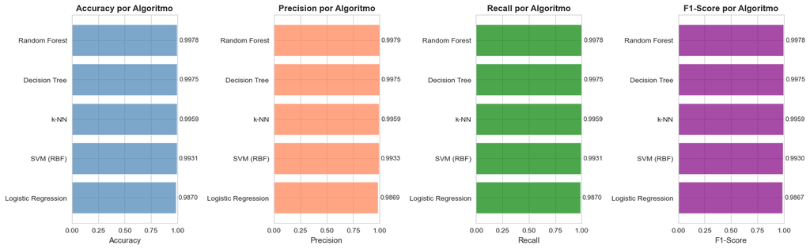

```
Mejor modelo: Random Forest (F1-Score: 0.9978)
```

```python
# ============================================
# VISUALIZACIÓN DE COMPARACIÓN
# ============================================

fig, axes = plt.subplots(1, 4, figsize=(16, 5))

metricas = ['Accuracy', 'Precision', 'Recall', 'F1-Score']
colores = ['steelblue', 'coral', 'green', 'purple']

for ax, metrica, color in zip(axes, metricas, colores):
    df_sorted = resultados_df.sort_values(metrica, ascending=True)
    ax.barh(df_sorted['Algoritmo'], df_sorted[metrica], color=color, alpha=0.7)
    ax.set_xlabel(metrica, fontsize=11)
    ax.set_title(f'{metrica} por Algoritmo', fontsize=12, fontweight='bold')
    ax.set_xlim([0, 1])
    for i, v in enumerate(df_sorted[metrica]):
        ax.text(v + 0.02, i, f'{v:.4f}', va='center', fontsize=9)

plt.tight_layout()
plt.savefig('02_comparacion_metricas.png', dpi=300, bbox_inches='tight')
plt.show()

# Mejor modelo
mejor_nombre = resultados_df.iloc[0]['Algoritmo']
print(f"\nMejor modelo: {mejor_nombre} (F1-Score: {resultados_df.iloc[0]['F1-Score']:.4f})")
```

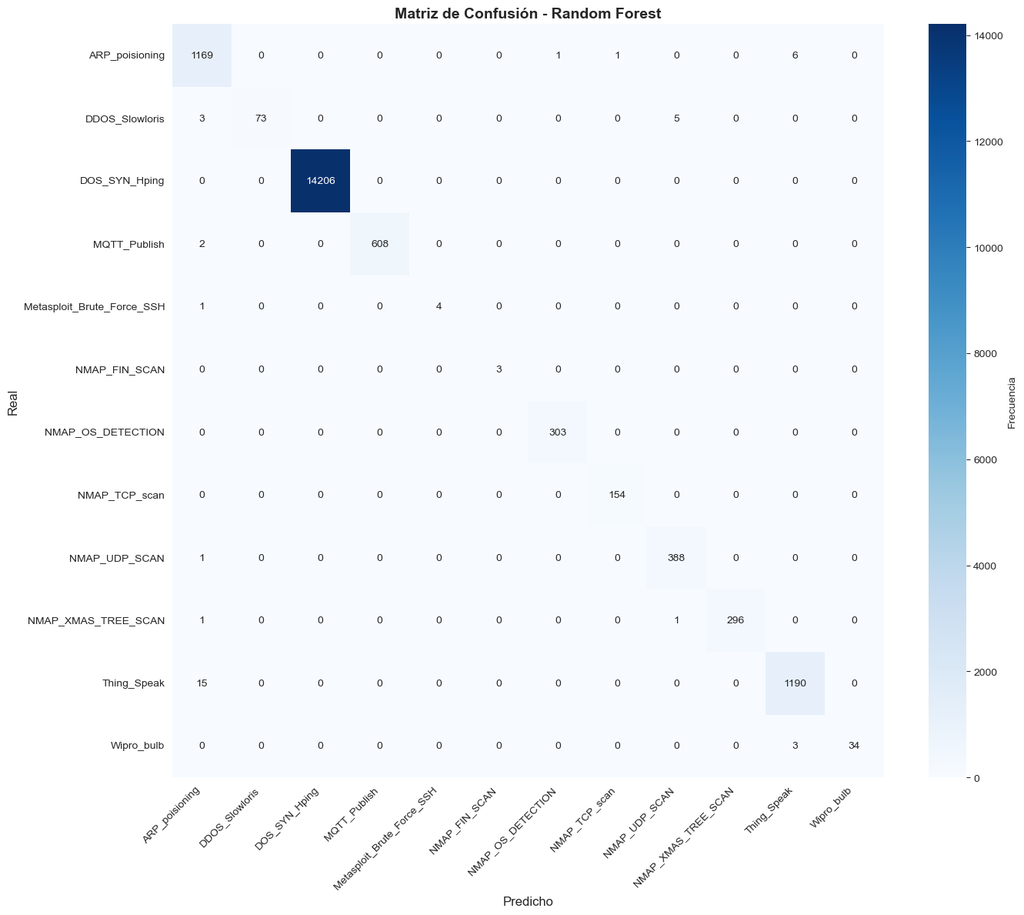

```
Classification Report - Mejor Modelo:
                            precision    recall  f1-score   support

            ARP_poisioning       0.98      0.99      0.99      1177
            DDOS_Slowloris       1.00      0.90      0.95        81
             DOS_SYN_Hping       1.00      1.00      1.00     14206
              MQTT_Publish       1.00      1.00      1.00       610
Metasploit_Brute_Force_SSH       1.00      0.80      0.89         5
             NMAP_FIN_SCAN       1.00      1.00      1.00         3
         NMAP_OS_DETECTION       1.00      1.00      1.00       303
             NMAP_TCP_scan       0.99      1.00      1.00       154
             NMAP_UDP_SCAN       0.98      1.00      0.99       389
       NMAP_XMAS_TREE_SCAN       1.00      0.99      1.00       298
               Thing_Speak       0.99      0.99      0.99      1205
                Wipro_bulb       1.00      0.92      0.96        37

                  accuracy                           1.00     18468
                 macro avg       1.00      0.97      0.98     18468
              weighted avg       1.00      1.00      1.00     18468
```

```python
# ============================================
# MATRIZ DE CONFUSIÓN DEL MEJOR MODELO
# ============================================

mejor_modelo = resultados[mejor_nombre]['modelo']
y_val_pred_mejor = resultados[mejor_nombre]['y_pred']

cm = confusion_matrix(y_val, y_val_pred_mejor)

plt.figure(figsize=(14, 12))
sns.heatmap(cm, annot=True, fmt='d', cmap='Blues',
            xticklabels=le_target.classes_,
            yticklabels=le_target.classes_,
            cbar_kws={'label': 'Frecuencia'})
plt.title(f'Matriz de Confusión - {mejor_nombre}', fontsize=14, fontweight='bold')
plt.xlabel('Predicho', fontsize=12)
plt.ylabel('Real', fontsize=12)
plt.xticks(rotation=45, ha='right')
plt.yticks(rotation=0)
plt.tight_layout()
plt.savefig('04_matriz_confusion_mejor_modelo.png', dpi=300, bbox_inches='tight')
plt.show()

print("\nClassification Report - Mejor Modelo:")
print(classification_report(y_val, y_val_pred_mejor,
                           target_names=le_target.classes_,
                           zero_division=0))
```

## Entrenamiento Final y Generación de Submission

Se reentrena el mejor modelo en el 100% de los datos de entrenamiento y se generan predicciones para el conjunto de test.

```python
# ============================================
# REENTRENAMIENTO EN TODO EL TRAIN
# ============================================

print(f"Reentrenando {mejor_nombre} en todo el dataset de entrenamiento...")

mejor_modelo_final = algoritmos[mejor_nombre]['modelo']
mejor_modelo_final.fit(X_scaled, y_enc)

print(f"Modelo reentrenado en {X_scaled.shape[0]} instancias")

# Predecir en test
y_test_pred_enc = mejor_modelo_final.predict(X_test_scaled)
y_test_pred = le_target.inverse_transform(y_test_pred_enc)

print(f"Predicciones generadas para {len(y_test_pred)} instancias de test")

# Distribución de predicciones
dist_pred = pd.Series(y_test_pred).value_counts()
print(f"\nDistribución de predicciones:")
display(dist_pred)
```

```
Reentrenando Random Forest en todo el dataset de entrenamiento...
Modelo reentrenado en 92337 instancias
Predicciones generadas para 24624 instancias de test

Distribución de predicciones:
```

```
DOS_SYN_Hping                 18925
Thing_Speak                    1674
ARP_poisioning                 1502
MQTT_Publish                    859
NMAP_UDP_SCAN                   518
NMAP_XMAS_TREE_SCAN             411
NMAP_OS_DETECTION               390
NMAP_TCP_scan                   178
DDOS_Slowloris                  100
Wipro_bulb                       49
NMAP_FIN_SCAN                    10
Metasploit_Brute_Force_SSH        8
Name: count, dtype: int64
```

```python
# ============================================
# CREAR ARCHIVO DE SUBMISSION
# ============================================

submission = pd.DataFrame({
    'id': test_ids.values,
    'Attack_type': y_test_pred
})

submission = submission[['id', 'Attack_type']]

# Validaciones
assert submission.shape[0] == test_df.shape[0], "Mismatch en número de filas"
assert submission['Attack_type'].isnull().sum() == 0, "Hay NaN en Attack_type"
assert submission['id'].isnull().sum() == 0, "Hay NaN en id"

# Guardar
submission.to_csv(f'submission_{mejor_nombre.replace(" ", "_").lower()}.csv', index=False)

print(f"Submission guardado: submission_{mejor_nombre.replace(' ', '_').lower()}.csv")
print(f"\nPrimeras 10 filas del submission:")
display(submission.head(10))
```

```
Submission guardado: submission_random_forest.csv

Primeras 10 filas del submission:
```

|  | id | Attack_type |
| --- | --- | --- |
| 0 | 7984 | DOS_SYN_Hping |
| 1 | 20470 | DOS_SYN_Hping |
| 2 | 14078 | DOS_SYN_Hping |
| 3 | 3651 | MQTT_Publish |
| 4 | 2240 | MQTT_Publish |
| 5 | 57589 | DOS_SYN_Hping |
| 6 | 87003 | DOS_SYN_Hping |
| 7 | 56579 | DOS_SYN_Hping |
| 8 | 8826 | DOS_SYN_Hping |
| 9 | 2473 | DOS_SYN_Hping |

```
Top 20 características más importantes:
```

|  | feature | importance |
| --- | --- | --- |
| 32 | fwd_pkts_payload.avg | 0.070643 |
| 31 | fwd_pkts_payload.tot | 0.067306 |
| 1 | id.resp_p | 0.065014 |
| 3 | service | 0.064475 |
| 29 | fwd_pkts_payload.min | 0.064011 |
| 30 | fwd_pkts_payload.max | 0.053165 |
| 62 | fwd_subflow_bytes | 0.046705 |
| 55 | flow_iat.max | 0.029265 |
| 42 | flow_pkts_payload.avg | 0.028227 |
| 54 | flow_iat.min | 0.027032 |
| 40 | flow_pkts_payload.max | 0.026945 |
| 72 | active.tot | 0.025336 |
| 4 | flow_duration | 0.023675 |
| 41 | flow_pkts_payload.tot | 0.020719 |
| 44 | fwd_iat.min | 0.020380 |
| 73 | active.avg | 0.019721 |
| 22 | fwd_PSH_flag_count | 0.017142 |
| 82 | fwd_last_window_size | 0.015639 |
| 35 | bwd_pkts_payload.max | 0.015550 |
| 25 | fwd_URG_flag_count | 0.014679 |

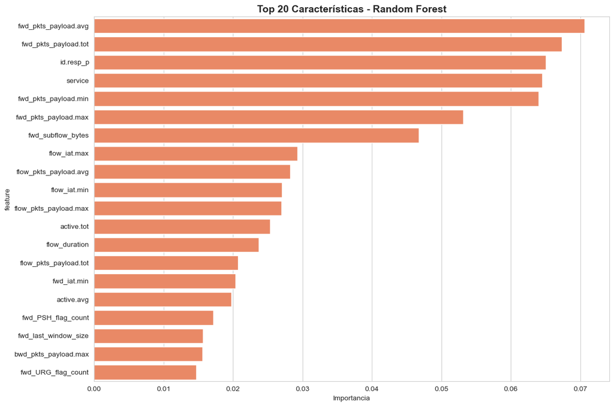

```python
# ============================================
# IMPORTANCIA DE CARACTERÍSTICAS (TOP 20)
# ============================================

# Para Random Forest o Decision Tree (tienen feature_importances_)
if hasattr(mejor_modelo, 'feature_importances_'):
    feature_importance = mejor_modelo.feature_importances_
    feature_names = X.columns

    imp_df = pd.DataFrame({
        'feature': feature_names,
        'importance': feature_importance
    }).sort_values('importance', ascending=False)

    print("Top 20 características más importantes:")
    display(imp_df.head(20))

    plt.figure(figsize=(12, 8))
    sns.barplot(data=imp_df.head(20), x='importance', y='feature', color='coral')
    plt.title(f'Top 20 Características - {mejor_nombre}', fontsize=14, fontweight='bold')
    plt.xlabel('Importancia')
    plt.tight_layout()
    plt.savefig('05_feature_importance.png', dpi=300, bbox_inches='tight')
    plt.show()
else:
    print("Este modelo no proporciona feature_importances_")
```